# Organizational Student Behavior

Zuhal

2023-08-13

# Data Exploration

## Import Library and Dataset

```r
df <- read_csv("Research Questionnaire.csv")
head(df)
```

```
## # A tibble: 6 × 29
##   Gender Student_Year  P1.1  P1.2  P1.3  P1.4  P1.5  P1.6  P1.7  P1.8  P1.9
##   <chr>         <dbl> <dbl> <dbl> <dbl> <dbl> <dbl> <dbl> <dbl> <dbl> <dbl>
## 1 Male           2018     2     2     3     5     3     2     3     3     4
## 2 Male           2017     5     5     4     5     4     4     4     4     4
## 3 Female         2020     4     3     4     4     4     4     3     3     5
## 4 Female         2020     3     4     4     4     3     4     4     4     4
## 5 Male           2020     1     2     3     3     1     3     2     1     3
## 6 Female         2019     4     2     3     4     3     3     3     3     4
## # ℹ 18 more variables: P1.10 <dbl>, P1.11 <dbl>, P1.12 <dbl>, P1.13 <dbl>,
## #   P2.1 <dbl>, P2.2 <dbl>, P2.3 <dbl>, P2.4 <dbl>, P2.5 <dbl>, P3.1 <dbl>,
## #   P3.2 <dbl>, P3.3 <dbl>, P3.4 <dbl>, P3.5 <dbl>, P3.6 <dbl>, P1_Total <dbl>,
## #   P2_Total <dbl>, P3_Total <dbl>
```

```r
codebook <- read.csv("codebook.csv")
codebook %>% as.list(codebook)
```

```
## $Variable.Name
##  [1] "P1_1"     "P1_2"     "P1_3"     "P1_4"     "P1_5"     "P1_6"
##  [7] "P1_7"     "P1_8"     "P1_9"     "P1_10"    "P1_11"    "P1_12"
## [13] "P1_13"    "P2_1"     "P2_2"     "P2_3"     "P2_4"     "P2_5"
## [19] "P3_1"     "P3_2"     "P3_3"     "P3_4"     "P3_5"     "P3_6"
## [25] "P1_Total" "P2_Total" "P3_Total"
##
## $Details
##  [1] "Organizations have clear goals"
##  [2] "Respect each other's members"
##  [3] "Access to adequate information"
##  [4] "The opportunity to express opinions"
##  [5] "Recognition of good performance or work"
##  [6] "The effectiveness of the monitoring and assessment system"
##  [7] "Mutual support among members of the organization"
```

[output cut: 20 more lines]

P1 = Organizational Climate P2 = Motivation P3 = Participation (Student participation in organization’s activity)

Rating Scale: Strongly Agree (5), Agree (4), Neutral (3), Disagree (2), Strongly Disagree (1)

```r
table(df$Gender)
```

```
##
## Female   Male
##     44     40
```

```r
table(df$Student_Year)
```

```
##
## 2017 2018 2019 2020
##   13   26   25   20
```

## Checking the Variables Correlation

```r
cor_df =round(cor(df[3:29]), 2)
# check the values in matrix form
# cor_df
cor_df1 <- as.data.frame(cor_df)
head(cor_df1)
```

```
##      P1.1 P1.2 P1.3 P1.4 P1.5 P1.6 P1.7 P1.8 P1.9 P1.10 P1.11 P1.12 P1.13 P2.1
## P1.1 1.00 0.66 0.48 0.50 0.47 0.43 0.52 0.40 0.60  0.66  0.62  0.46  0.66 0.32
## P1.2 0.66 1.00 0.55 0.60 0.55 0.55 0.66 0.62 0.58  0.68  0.59  0.52  0.62 0.38
## P1.3 0.48 0.55 1.00 0.40 0.44 0.59 0.51 0.54 0.53  0.59  0.52  0.42  0.53 0.36
## P1.4 0.50 0.60 0.40 1.00 0.49 0.31 0.49 0.43 0.57  0.51  0.45  0.55  0.39 0.30
## P1.5 0.47 0.55 0.44 0.49 1.00 0.54 0.56 0.57 0.42  0.62  0.50  0.30  0.51 0.38
## P1.6 0.43 0.55 0.59 0.31 0.54 1.00 0.60 0.62 0.37  0.68  0.49  0.40  0.53 0.22
##      P2.2 P2.3 P2.4 P2.5  P3.1 P3.2 P3.3 P3.4 P3.5 P3.6 P1_Total P2_Total
## P1.1 0.25 0.35 0.25 0.20  0.16 0.20 0.40 0.37 0.26 0.21     0.76     0.36
## P1.2 0.29 0.45 0.41 0.21  0.15 0.24 0.37 0.38 0.35 0.34     0.84     0.47
## P1.3 0.23 0.34 0.42 0.20  0.18 0.39 0.31 0.28 0.15 0.23     0.72     0.42
## P1.4 0.34 0.37 0.34 0.33  0.13 0.18 0.28 0.29 0.26 0.17     0.68     0.44
## P1.5 0.21 0.23 0.24 0.15  0.07 0.24 0.23 0.23 0.20 0.04     0.71     0.33
## P1.6 0.14 0.34 0.19 0.13 -0.03 0.19 0.22 0.32 0.22 0.23     0.72     0.27
##      P3_Total
## P1.1     0.36
## P1.2     0.42
## P1.3     0.35
## P1.4     0.30
## P1.5     0.23
## P1.6     0.26
```

```r
df_score <- df[3:29]
p_values <- rcorr(as.matrix(df_score))
# Check if you need
# p_values
```

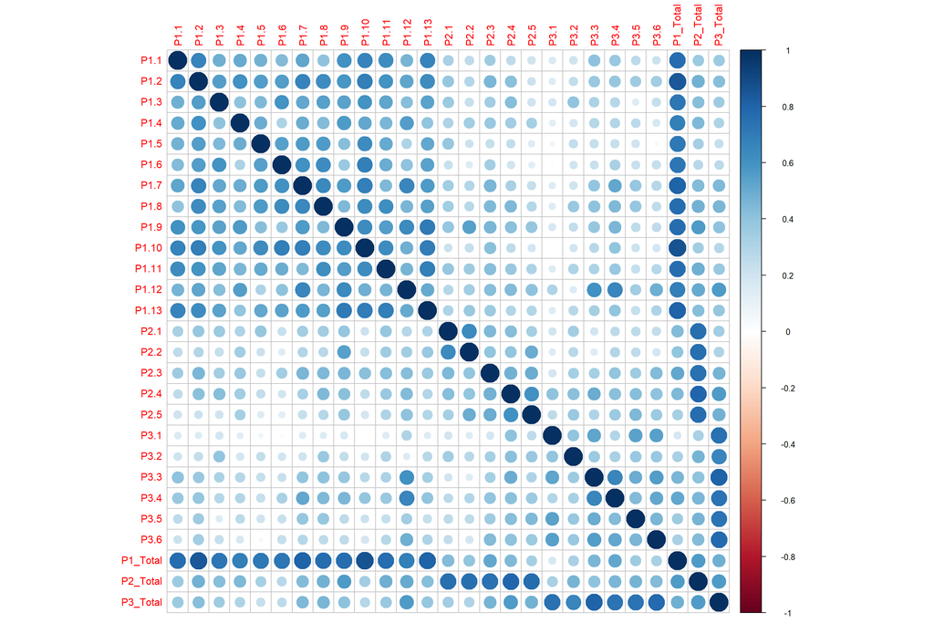

```r
corrplot(cor_df, method = "circle")
```

## Exploring Variable x1 (Organizational Climate) on x2 (Motivation) and y (Participation)

Make a visualization function to get a better view of each variables correlation

```r
corrplot2 <- function(data,
                      method = "pearson",
                      sig.level = 0.05,
                      order = "original",
                      diag = FALSE,
                      type = "upper",
                      tl.srt = 90,
                      number.font = 1,
                      number.cex = 1,
                      mar = c(0, 0, 0, 0)) {
  library(corrplot)
  data_incomplete <- data
  data <- data[complete.cases(data), ]
  mat <- cor(data, method = method)
  cor.mtest <- function(mat, method) {
    mat <- as.matrix(mat)
    n <- ncol(mat)
    p.mat <- matrix(NA, n, n)
    diag(p.mat) <- 0
    for (i in 1:(n - 1)) {
      for (j in (i + 1):n) {
        tmp <- cor.test(mat[, i], mat[, j], method = method)
        p.mat[i, j] <- p.mat[j, i] <- tmp$p.value
      }
    }
    colnames(p.mat) <- rownames(p.mat) <- colnames(mat)
    p.mat
  }
  p.mat <- cor.mtest(data, method = method)
  col <- colorRampPalette(c("#BB4444", "#EE9988", "#FFFFFF", "#77AADD", "#4477AA"))
  corrplot(mat,
    method = "color", col = col(200), number.font = number.font,
    mar = mar, number.cex = number.cex,
    type = type, order = order,
    addCoef.col = "black", # add correlation coefficient
    tl.col = "black", tl.srt = tl.srt, # rotation of text labels
    # combine with significance level
    p.mat = p.mat, sig.level = sig.level, insig = "blank",
    # hide correlation coefficiens on the diagonal
    diag = diag
  )
}
```

```r
organizational_climate <- df_score[1:13]
total_score <- df_score[26:27]
organizational_climate <- cbind(organizational_climate, total_score)
```

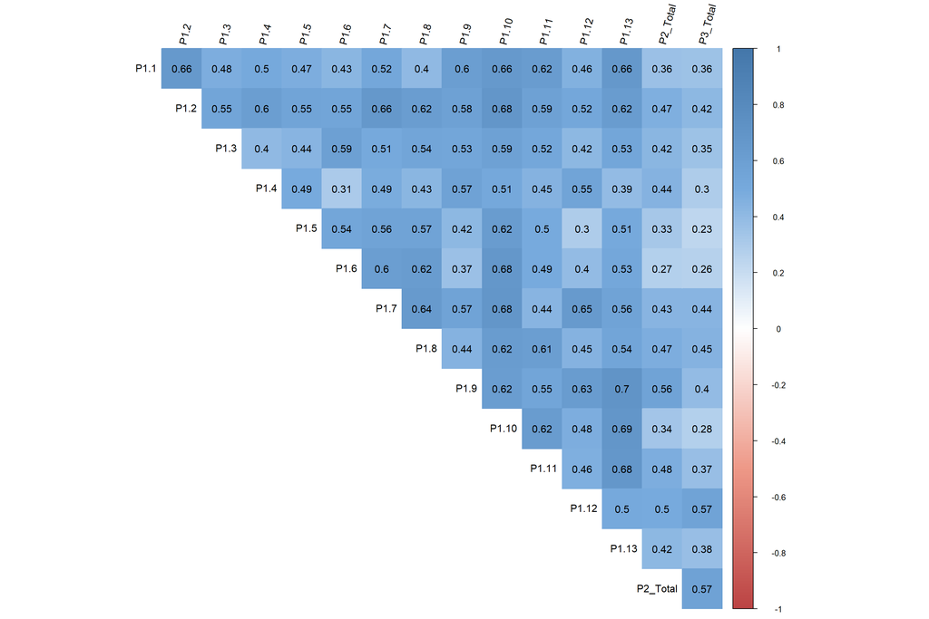

```r
# width = 15, height = 10
corrplot2(
    data = organizational_climate,
    method = "pearson",
    sig.level = 0.05,
    order = "original",
    diag = FALSE,
    type = "upper",
    tl.srt = 75
)
```

Note: Corr value >= 0.45

1. Organizational Climate (P1.2, P1.8, P1.9, P1.11, P1.12) to Motivation (P2_Total)
2. Organizational Climate (P1.8, P1.12) to Participation (P3_Total)

## Exploring Variables Indicators or Questions.

```r
subset_df <- data.frame()
subset_df <- df[,c("Gender", "Student_Year", "P1.2", "P1.8", "P1.9",
                   "P1.11", "P1.12", "P2_Total", "P3_Total")]
subset_df$Student_Year <- as.character(subset_df$Student_Year)
head(subset_df)
```

```
## # A tibble: 6 × 9
##   Gender Student_Year  P1.2  P1.8  P1.9 P1.11 P1.12 P2_Total P3_Total
##   <chr>  <chr>        <dbl> <dbl> <dbl> <dbl> <dbl>    <dbl>    <dbl>
## 1 Male   2018             2     3     4     4     3       19       10
## 2 Male   2017             5     4     4     5     4       22       26
## 3 Female 2020             3     3     5     3     3       22       17
## 4 Female 2020             4     4     4     3     4       19       19
## 5 Male   2020             2     1     3     2     4       22       21
## 6 Female 2019             2     3     4     3     3       18       21
```

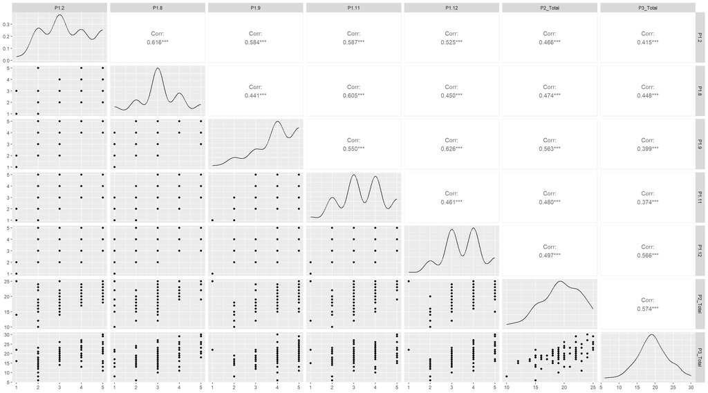

```r
#create scatterplot matrix
ggpairs(subset_df[3:9])
```

### Organization Climate on Motivation and Participation

P1.12 Statement: “I have an alignment of goal with organizational goals.”

```r
glimpse(subset_df)
```

```
## Rows: 84
## Columns: 9
## $ Gender       <chr> "Male", "Male", "Female", "Female", "Male", "Female", "Ma…
## $ Student_Year <chr> "2018", "2017", "2020", "2020", "2020", "2019", "2019", "…
## $ P1.2         <dbl> 2, 5, 3, 4, 2, 2, 3, 4, 3, 5, 3, 3, 2, 4, 4, 5, 2, 4, 2, …
## $ P1.8         <dbl> 3, 4, 3, 4, 1, 3, 4, 5, 3, 3, 3, 4, 2, 4, 3, 5, 2, 3, 3, …
## $ P1.9         <dbl> 4, 4, 5, 4, 3, 4, 5, 4, 4, 5, 4, 4, 5, 4, 5, 5, 2, 5, 3, …
## $ P1.11        <dbl> 4, 5, 3, 3, 2, 3, 4, 3, 4, 4, 4, 2, 3, 4, 4, 5, 2, 5, 3, …
## $ P1.12        <dbl> 3, 4, 3, 4, 4, 3, 4, 4, 3, 4, 4, 3, 4, 4, 3, 3, 3, 4, 3, …
## $ P2_Total     <dbl> 19, 22, 22, 19, 22, 18, 22, 19, 19, 20, 20, 20, 16, 20, 2…
## $ P3_Total     <dbl> 10, 26, 17, 19, 21, 21, 20, 20, 21, 23, 17, 18, 18, 26, 2…
```

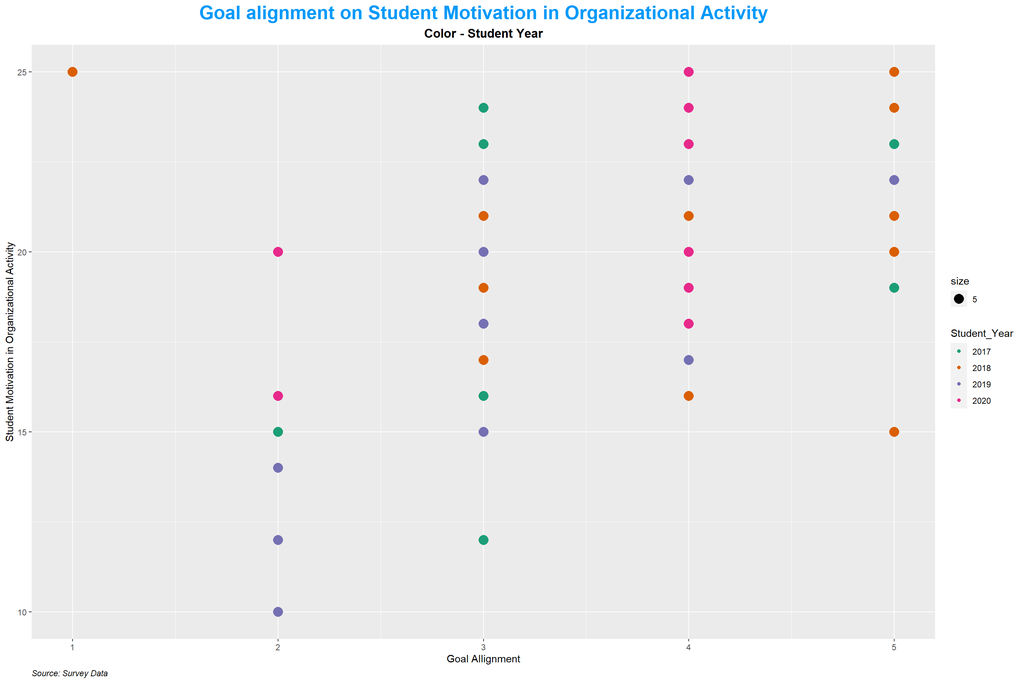

```r
ggplot(subset_df, aes(x = P1.12, y = P2_Total)) +
  geom_point(aes(size = 5, color = Student_Year)) +
  scale_color_brewer(palette="Dark2") +
  labs(
    title = "Goal alignment on Student Motivation in Organizational Activity",
    subtitle = "Color - Student Year",
    caption = "Source: Survey Data",
    x = "Goal Allignment",
    y = "Student Motivation in Organizational Activity"
  ) +
  theme(
    plot.title = element_text(color = "#0099f9", size = 20, face =
                              "bold", hjust = 0.5),
    plot.subtitle = element_text(size = 13, face = "bold", hjust = 0.5),
    plot.caption = element_text(face = "italic", hjust = 0)
  )
```

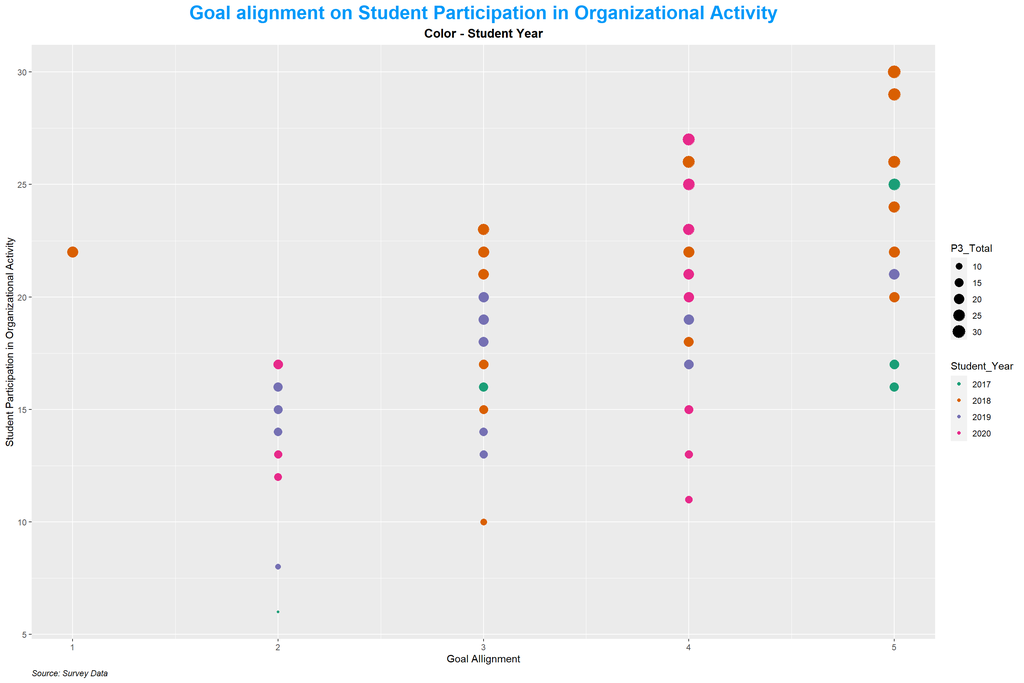

```r
ggplot(subset_df, aes(x = P1.12, y = P3_Total)) +
  geom_point(aes(size = P3_Total, color = Student_Year)) +
  scale_color_brewer(palette="Dark2") +
  labs(
    title = "Goal alignment on Student Participation in Organizational Activity",
    subtitle = "Color - Student Year",
    caption = "Source: Survey Data",
    x = "Goal Allignment",
    y = "Student Participation in Organizational Activity"
  ) +
  theme(
    plot.title = element_text(color = "#0099f9", size = 20, face =
                              "bold", hjust = 0.5),
    plot.subtitle = element_text(size = 13, face = "bold", hjust = 0.5),
    plot.caption = element_text(face = "italic", hjust = 0)
  )
```

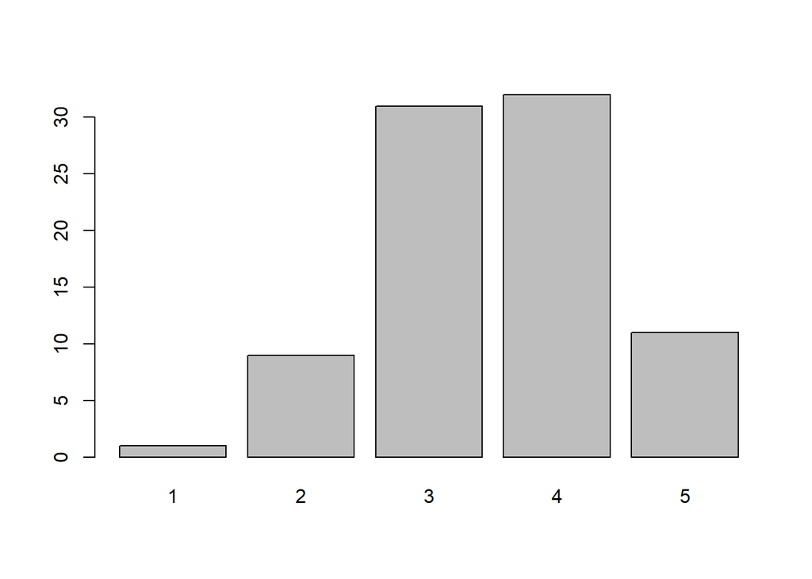

```r
p1.12 <- table(subset_df$P1.12)
barplot(p1.12)
```

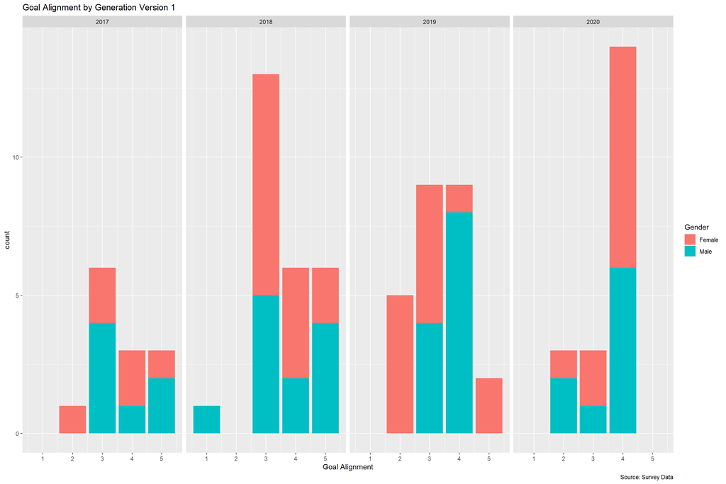

```r
ggplot(subset_df, aes(x = P1.12, fill = Gender)) +
  geom_bar() +
  labs(title = "Goal Alignment by Generation Version 1",
       caption = "Source: Survey Data",
       x = "Goal Alignment") +
  facet_grid(~Student_Year)
```

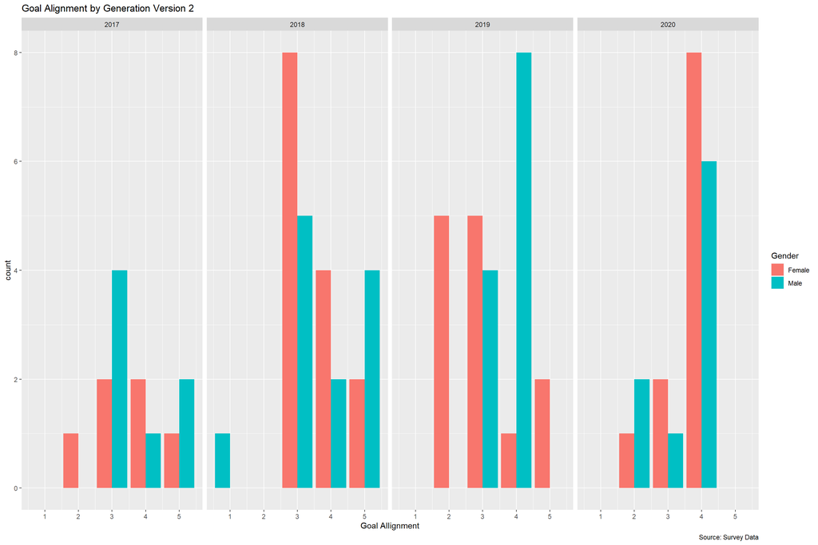

```r
ggplot(data = subset_df, aes(x = P1.12,  fill = Gender)) +
  geom_bar(position = position_dodge(preserve = "single")) +
  labs(
    title = "Goal Alignment by Generation Version 2",
    caption = "Source: Survey Data",
    x = "Goal Allignment") +
  facet_grid(~Student_Year)
```

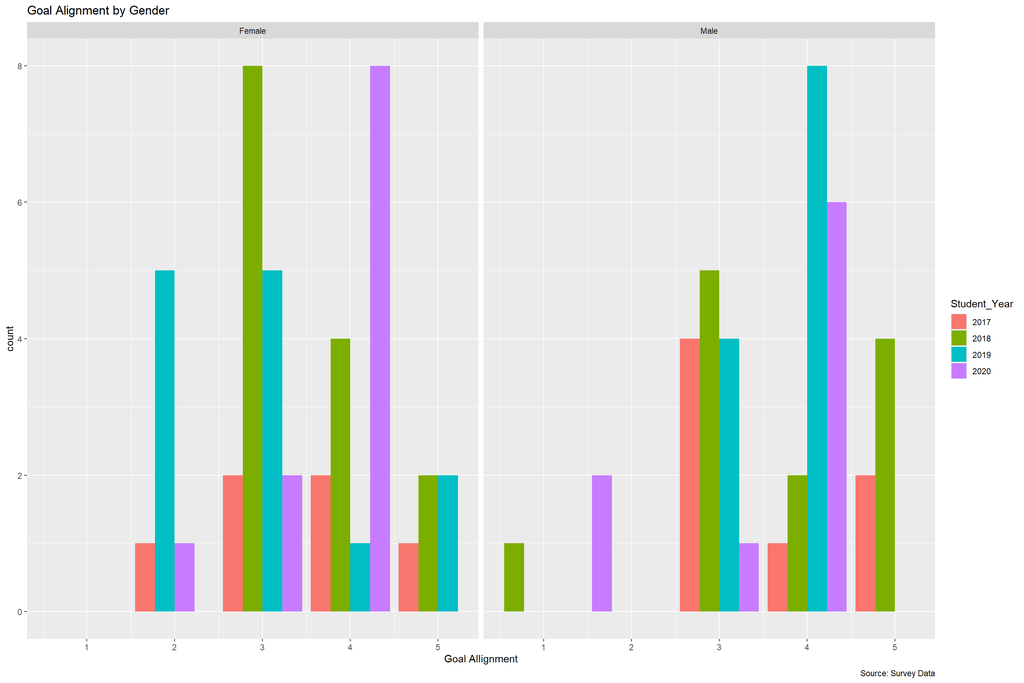

```r
ggplot(data = subset_df, aes(x = P1.12,  fill = Student_Year)) +
  geom_bar(position = position_dodge(preserve = "single")) +
  labs(
    title = "Goal Alignment by Gender",
    caption = "Source: Survey Data",
    x = "Goal Allignment") +
  facet_grid(~Gender)
```

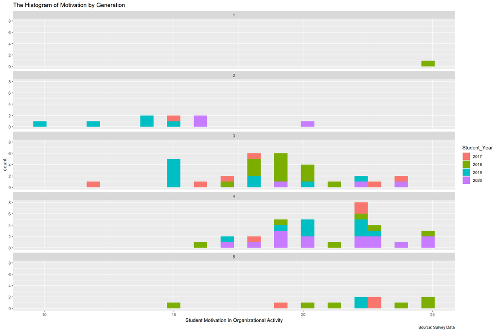

```r
ggplot(subset_df, aes(x= P2_Total))+
  geom_histogram(aes(fill = Student_Year)) +
  labs(
    title = "The Histogram of Motivation by Generation",
    caption = "Source: Survey Data",
    x = "Student Motivation in Organizational Activity") +
  facet_wrap(~P1.12, ncol = 1)
```

## Linear Regression

### Linear Regression with Only Selected Variables

```r
# Fit the multiple linear regression model on variable y (Participation)
participation_model = lm(formula = P3_Total ~ P1.2 + P1.8 + P1.9 +
                                P1.11 + P1.12, data = subset_df)
```

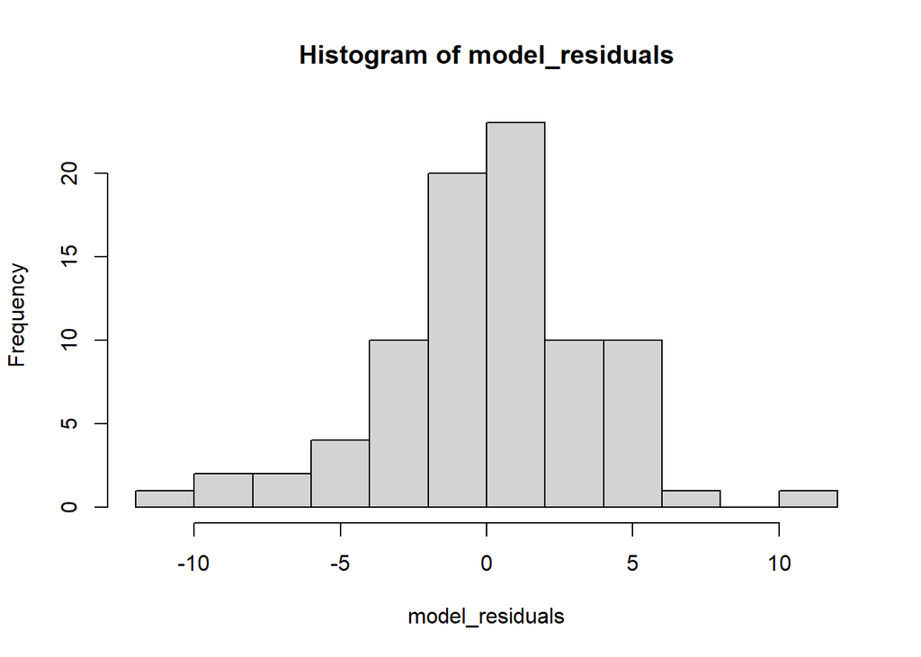

```r
# Get the model residuals
model_residuals = participation_model$residuals

# Plot the result
hist(model_residuals)
```

The graph looks like a bell curve

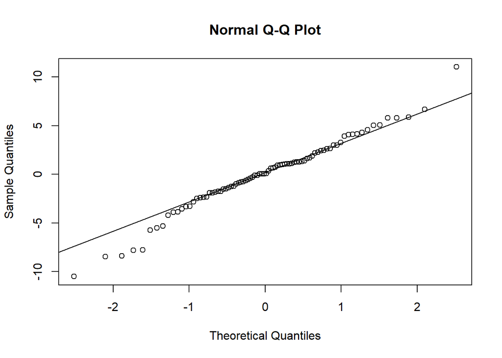

```r
# Plot the residuals
qqnorm(model_residuals)
# Plot the Q-Q line
qqline(model_residuals)
```

From the plot, we can observe that almost all portions of the residuals lie in a straight line. Then we can assume that the residuals of the model follow a normal distribution.

Multicollinearity assumption check:

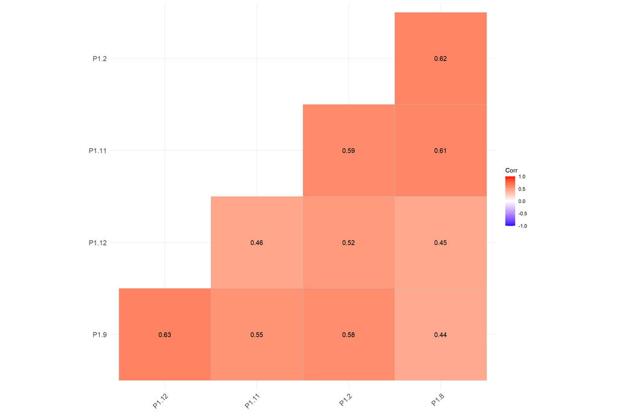

```r
# Remove the Customer Value column
reduced_data <- subset_df %>%  select(-c(Gender, Student_Year,
                                            P2_Total, P3_Total))

# Compute correlation at 2 decimal places
corr_matrix = round(cor(reduced_data), 2)

# Compute and show the  result
ggcorrplot(corr_matrix, hc.order = TRUE, type = "lower",
          lab = TRUE)
```

We can notice there is no strong correlations because all of the value is lower than 0.8.

```r
summary(participation_model)
```

```
##
## Call:
## lm(formula = P3_Total ~ P1.2 + P1.8 + P1.9 + P1.11 + P1.12, data = subset_df)
##
## Residuals:
##      Min       1Q   Median       3Q      Max
## -10.4928  -1.8405   0.0587   2.2151  11.0182
##
## Coefficients:
##             Estimate Std. Error t value Pr(>|t|)
## (Intercept)  7.49476    1.96191   3.820 0.000266 ***
## P1.2         0.18589    0.53877   0.345 0.731002
## P1.8         0.97972    0.56983   1.719 0.089523 .
## P1.9        -0.04938    0.61177  -0.081 0.935879
## P1.11        0.08656    0.57003   0.152 0.879696
## P1.12        2.28422    0.62058   3.681 0.000426 ***
## ---
## Signif. codes:  0 '***' 0.001 '**' 0.01 '*' 0.05 '.' 0.1 ' ' 1
##
## Residual standard error: 3.79 on 78 degrees of freedom
## Multiple R-squared:  0.369,  Adjusted R-squared:  0.3285
## F-statistic: 9.121 on 5 and 78 DF,  p-value: 7.306e-07
```

The model has an adjusted R-square of 0.33 or 33% of the target variance can be explained by this model features. As we can see, our P1.12 indicators is the only significant variable.

### Linear Regression With All Variables

```r
# Fit the multiple linear regression model on variable y (Participation)
participation_model2 = lm(formula = P3_Total ~ P1.1 + P1.2 + P1.3 +
                                P1.4 + P1.5 + P1.6 + P1.7 + P1.8 +
                                P1.9 + P1.10 + P1.11 + P1.12,
                                data = df)
```

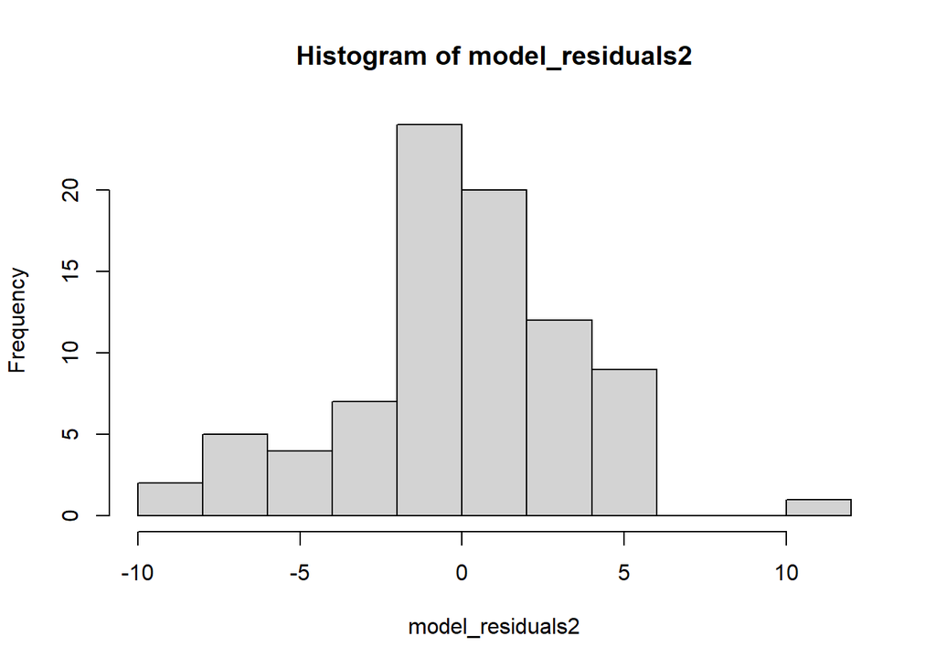

```r
# Get the model residuals
model_residuals2 = participation_model2$residuals

# Plot the result
hist(model_residuals2)
```

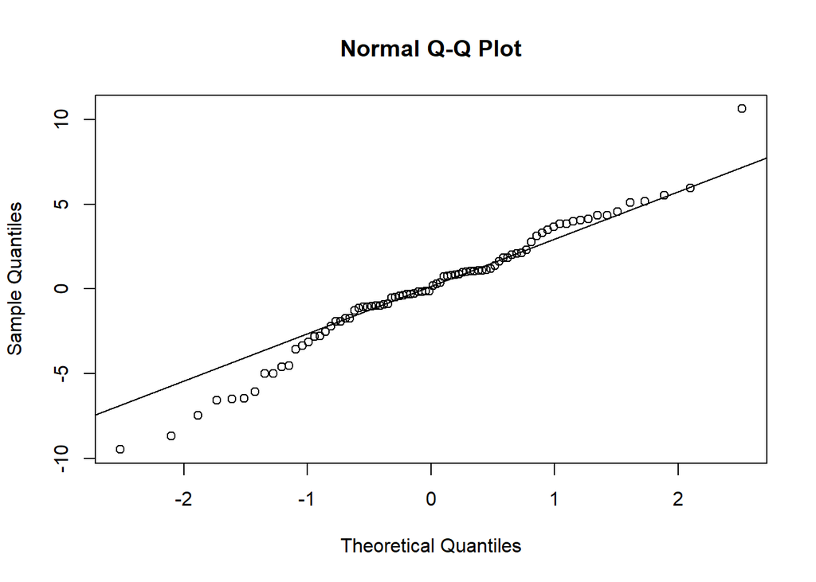

```r
# Plot the residuals
qqnorm(model_residuals2)
# Plot the Q-Q line
qqline(model_residuals2)
```

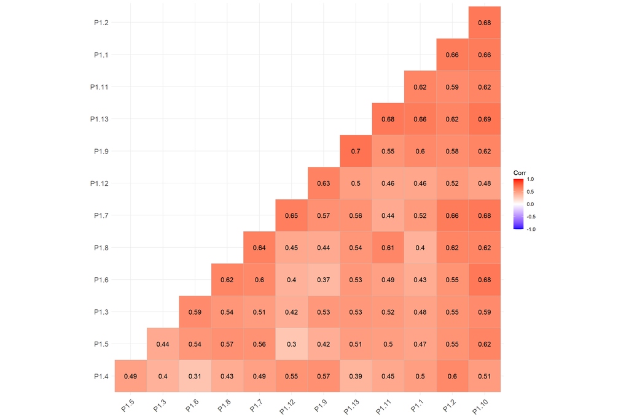

```r
# Remove the Customer Value column
reduced_data2 <- df %>%  select(-c(Gender, Student_Year,
                                   P1_Total, P2_Total, P3_Total))
reduced_data2 <- reduced_data2 %>%  select(-c(14:24))

# Compute correlation at 2 decimal places
corr_matrix = round(cor(reduced_data2), 2)

# Compute and show the  result
ggcorrplot(corr_matrix, hc.order = TRUE, type = "lower",
          lab = TRUE)
```

We can notice there is no strong correlations because all of the value is lower than 0.8.

```r
summary(participation_model2)
```

```
##
## Call:
## lm(formula = P3_Total ~ P1.1 + P1.2 + P1.3 + P1.4 + P1.5 + P1.6 +
##     P1.7 + P1.8 + P1.9 + P1.10 + P1.11 + P1.12, data = df)
##
## Residuals:
##     Min      1Q  Median      3Q     Max
## -9.4659 -1.7302  0.0422  2.0338 10.6177
##
## Coefficients:
##             Estimate Std. Error t value Pr(>|t|)
## (Intercept)  7.99568    2.16583   3.692 0.000434 ***
## P1.1         0.72626    0.64349   1.129 0.262850
## P1.2         0.43074    0.63647   0.677 0.500754
## P1.3         0.49218    0.60991   0.807 0.422372
## P1.4        -0.59513    0.57010  -1.044 0.300072
## P1.5        -0.01191    0.56451  -0.021 0.983226
## P1.6        -0.48328    0.65029  -0.743 0.459823
## P1.7         0.14336    0.72809   0.197 0.844467
## P1.8         1.44355    0.67823   2.128 0.036775 *
## P1.9         0.08584    0.68307   0.126 0.900353
## P1.10       -1.29829    0.80218  -1.618 0.110002
## P1.11        0.07388    0.64884   0.114 0.909666
## P1.12        2.37944    0.72783   3.269 0.001665 **
## ---
## Signif. codes:  0 '***' 0.001 '**' 0.01 '*' 0.05 '.' 0.1 ' ' 1
##
## Residual standard error: 3.8 on 71 degrees of freedom
## Multiple R-squared:  0.4226, Adjusted R-squared:  0.325
## F-statistic:  4.33 on 12 and 71 DF,  p-value: 3.929e-05
```

We still have P1.12 significant with additional indicator that is P1.8. However, our adjusted R-square a bit lower than the previous value 0.32.

There are still a lot of various indicators that can be explored, especially those with codes P2 (Motivation) and P3 (Participation).